# Predicting heart disease with classification trees

Dario Molina

April 11, 2017

### Introduction

With this report, heart disease data will be analyzed along with tree classification to predict whether a person has heart disease or not.

```r
> library(rpart)
> library(rpart.plot)
> library(maptree)
Loading required package: cluster
> library(caret)
Loading required package: lattice
Loading required package: ggplot2
> # the following utility files can be found attached to the assignment
> source("https://raw.githubusercontent.com/grbruns/cst383/master/lin-regr-util.R")
> source("https://raw.githubusercontent.com/grbruns/cst383/master/class-util.R")
```

### Reading and preprocessing the data

Obtaining data from https://raw.githubusercontent.com/grbruns/cst383/master/heart.dat. The column names of the data frame have been set and converted the range of heart output to 0 and 1. 0 representing the person does not have heart disease and vice versa.

```r
>  heart = read.table("https://raw.githubusercontent.com/grbruns/cst383/master/heart.dat", quote = "/")
>  names(heart) <- c("AGE", "SEX", "CHESTPAIN", "RESTBP", "CHOL",
+                    "SUGAR", "ECG", "MAXHR", "ANGINA", "DEP", "EXERCISE", "FLUOR",
+                    "THAL", "OUTPUT")
>  names(heart) = tolower(names(heart))
>
>  # convert output to 0-1 range
>  bad.ouput = heart$output
>  heart$output = heart$output - 1
>
>  # categorical variables to factors
>  heart$sex = factor(heart$sex)
>  heart$sugar = factor(heart$sugar)
>  heart$angina = factor(heart$angina)
>  heart$chestpain = factor(heart$chestpain)
>  heart$ecg = factor(heart$ecg)
>  heart$thal = factor(heart$thal)
>  heart$exercise = factor(heart$exercise)
>
> # convert output to factor
> heart$output = factor(heart$output)
```

### Data exploration

The mean age of the human subjects in the data is about 55 years old.

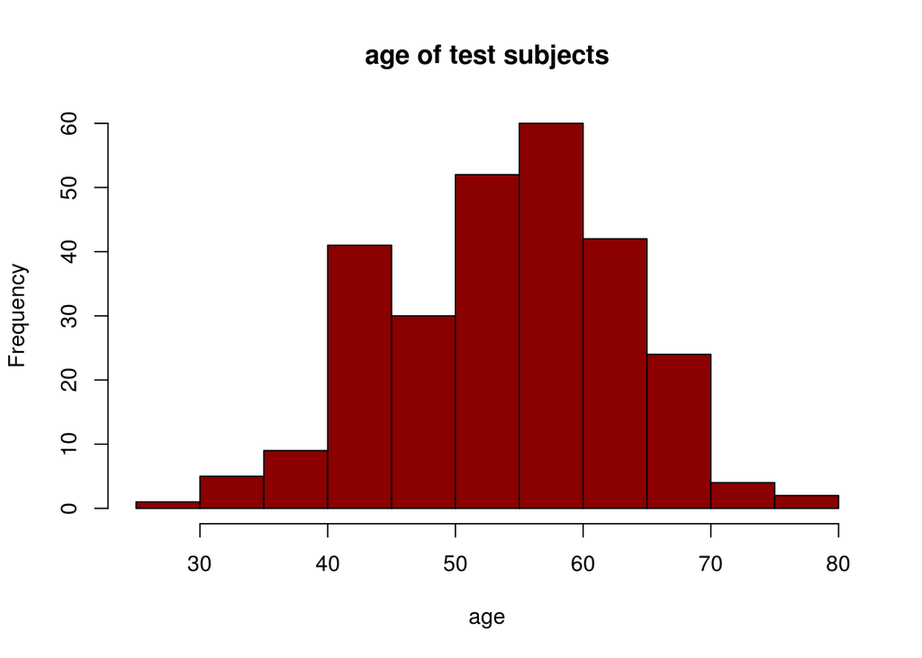

```r
> hist(heart$age, main="age of test subjects", xlab="age", col="red4")
```

From a grid of scatterplots of the numeric features, it appears that no pairs of features are strongly correlated.

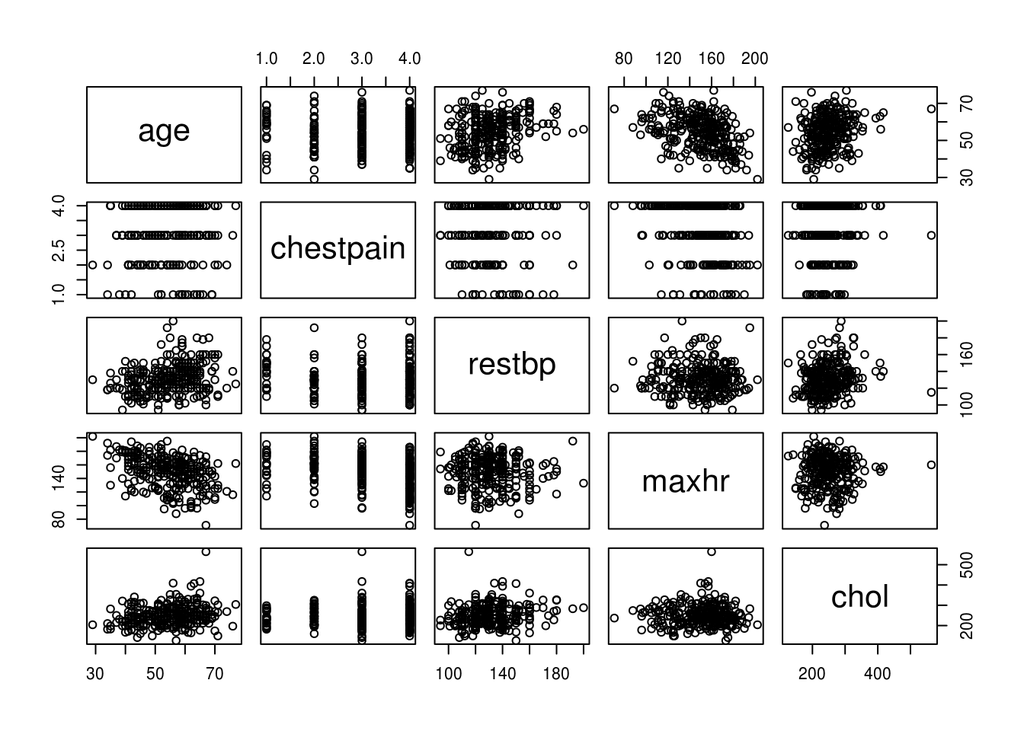

```r
> plot(heart[,c("age","chestpain","restbp","maxhr","chol")])
```

[figure not shown]

```r
>  plot(heart$maxhr[heart$output == 1],heart$restbp[heart$output == 1], col="green", main = "heart disease by resting blood pressure and max heart rate", xlab = "maxhr",ylab="restbp")
>  lines(heart$maxhr[heart$output == 0],heart$restbp[heart$output == 0], col="red", type ="p" )
>   legend("topleft", legend=c("heart disease", "no heart disease"),col=c("red", "green"), lty=1:1, cex=0.8)
```

### Building a classification tree

From the scatterplot above, I’ll utilize some of the features for our model.

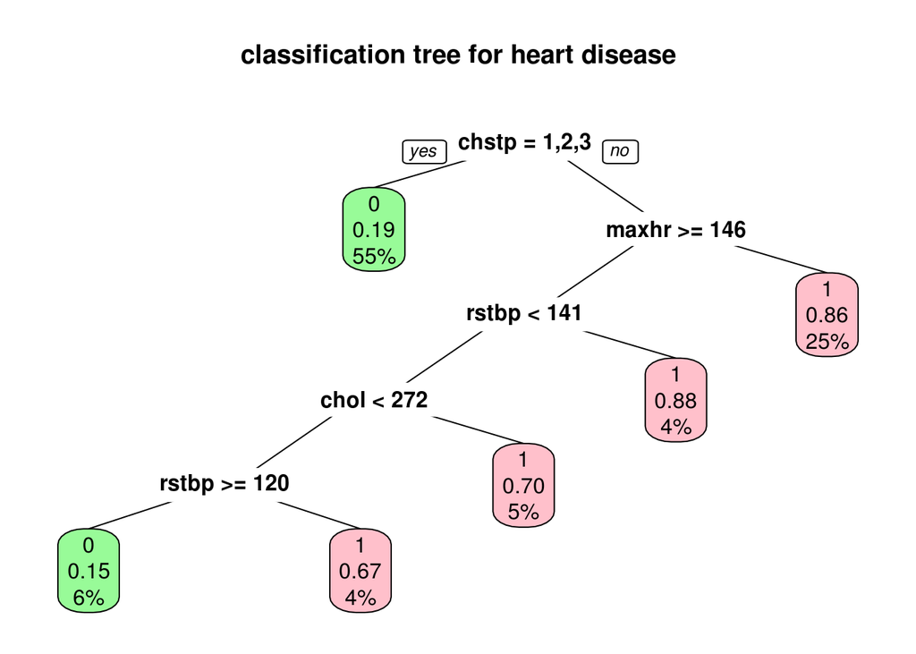

```r
> # training and test sets
> set.seed(132)
> split = split_data(heart)
> tr_dat = split[[1]]
> te_dat = split[[2]]
>
>
> fit = rpart(output ~ chestpain + restbp + maxhr + chol,data=tr_dat, method="class")
>
> prp(fit, extra=106, varlen=5,
+  main="classification tree for heart disease",
+  box.col=c("palegreen", "pink")[fit$frame$yval])
```

Based on the summary from fit, we can see the most important variable is chestpain, followed by maxhr. We can also see that for node 1, there were 201 observations and going to node 2 the number observations had a big drop. For the following nodes the observations had small differences. It also seems like “chol” it isn’t as relevant as the other features.

```r
> summary(fit)
```

```
Call:
rpart(formula = output ~ chestpain + restbp + maxhr + chol, data = tr_dat,
    method = "class")
  n= 201

          CP nsplit rel error    xerror       xstd
1 0.46511628      0 1.0000000 1.0000000 0.08156459
2 0.02325581      1 0.5348837 0.5348837 0.06925455
3 0.01000000      5 0.4302326 0.6279070 0.07307336

Variable importance
chestpain     maxhr    restbp      chol
       54        26        12         9

Node number 1: 201 observations,    complexity param=0.4651163
  predicted class=0  expected loss=0.4278607  P(node) =1
    class counts:   115    86
   probabilities: 0.572 0.428
  left son=2 (111 obs) right son=3 (90 obs)
  Primary splits:
      chestpain splits as  LLLR,      improve=28.242800, (0 missing)
      maxhr     < 147.5 to the right, improve=16.933520, (0 missing)
      chol      < 273.5 to the left,  improve= 5.515416, (0 missing)
      restbp    < 162.5 to the left,  improve= 4.005182, (0 missing)
  Surrogate splits:
      maxhr  < 147.5 to the right, agree=0.687, adj=0.300, (0 split)
      chol   < 281.5 to the left,  agree=0.572, adj=0.044, (0 split)
      restbp < 162.5 to the left,  agree=0.567, adj=0.033, (0 split)

Node number 2: 111 observations
  predicted class=0  expected loss=0.1891892  P(node) =0.5522388
    class counts:    90    21
   probabilities: 0.811 0.189

Node number 3: 90 observations,    complexity param=0.02325581
  predicted class=1  expected loss=0.2777778  P(node) =0.4477612
    class counts:    25    65
   probabilities: 0.278 0.722
  left son=6 (40 obs) right son=7 (50 obs)
  Primary splits:
```

[output cut: 51 more lines]

```

Node number 25: 10 observations
  predicted class=1  expected loss=0.3  P(node) =0.04975124
    class counts:     3     7
   probabilities: 0.300 0.700

Node number 48: 13 observations
  predicted class=0  expected loss=0.1538462  P(node) =0.06467662
    class counts:    11     2
   probabilities: 0.846 0.154

Node number 49: 9 observations
  predicted class=1  expected loss=0.3333333  P(node) =0.04477612
    class counts:     3     6
   probabilities: 0.333 0.667
```

### Classifying test data

We run our model on the test data, and classify examples in the test data using a threshold of 0.5.

The summary output from our fit only gives a rough idea of the usefulness of our model. For a better idea we should use the model as a classifier and see how well it predicts heart disease on the test data.

```r
> predicted = predict(fit, te_dat, type="prob")
> predictors = as.data.frame(predicted)
> names(predictors) = c("zero","one")
> y = predictors$one
> predicts = as.numeric(y > 0.5)
> actuals = te_dat$output
> confusion_matrix=table(actuals, predicts)
> confusion_matrix
```

```
       predicts
actuals  0  1
      0 25 10
      1 14 20
```

The accuracy of our classifier is not that bad, but is not that good either.

```r
>  succ_rate = mean(predicts == actuals)
>  round(succ_rate, 3)
```

```
[1] 0.652
```

### Assessing the model

Looking at the output of the model on test cases where heart disease is present, and on test cases where heart disease is not present, we can see that the model is not working especially well. We can also see that a classification threshold of about 0.5 is probably about right.

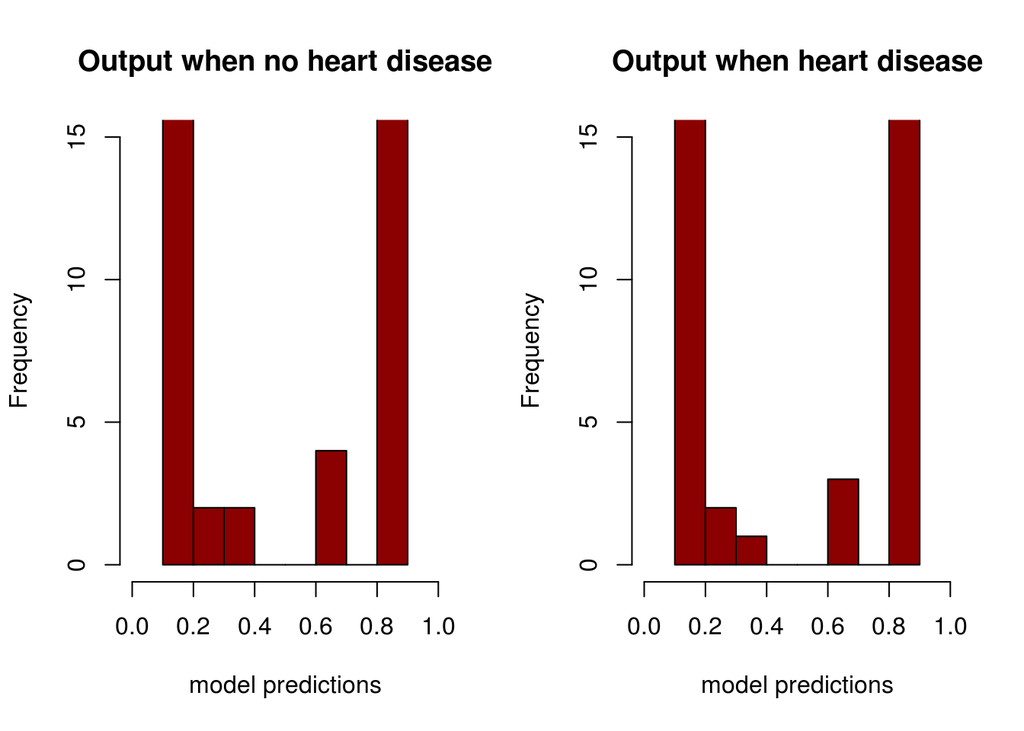

```r
> par(mfrow=c(1,2))
>  hist(predicted[actuals == 0], main="Output when no heart disease", breaks=10, xlim=c(0,1), ylim=c(0,15),col="red4", xlab="model predictions")
>
>  hist(predicted[actuals == 1], main="Output when heart disease", breaks=10, xlim=c(0,1), ylim=c(0,15), col="red4", xlab="model predictions")
```

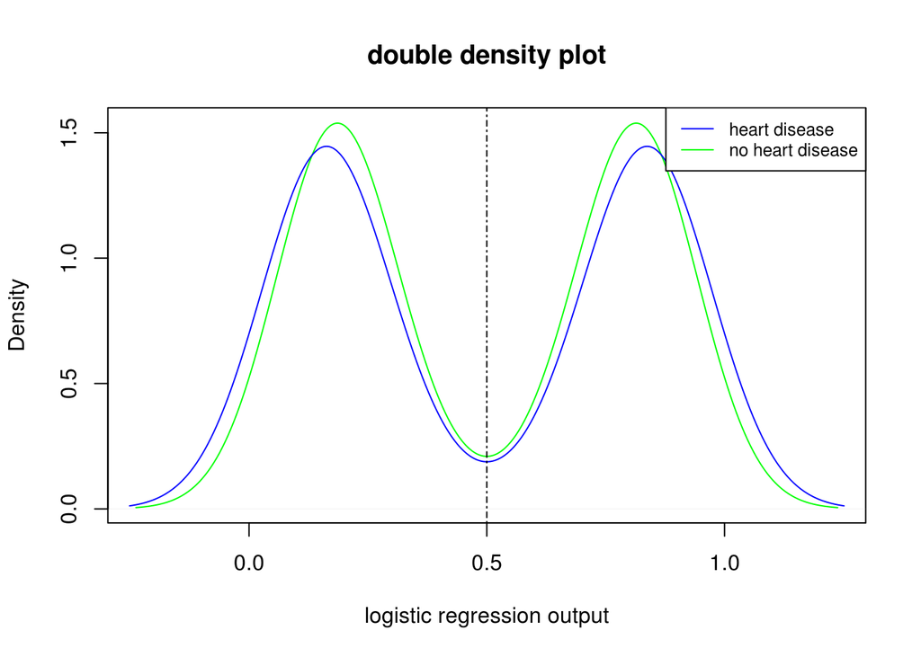

```r
>  par(mfrow=c(1,1))
>  plot(density(predicted[actuals == 0]), main="double density plot", col="green",xlab="logistic regression output")
>  lines(density(predicted[actuals == 1]),col="blue")
>  abline(a=NULL,b=0,h=NULL,v=0.5,lty=4)
>  legend("topright", legend=c("heart disease", "no heart disease"),col=c("blue", "green"), lty=1:1, cex=0.8)
```

```r
>  prec_recall_summary = function(predicts, actuals) {
+    thresh = seq(0, 1, length.out=69)
+    prec_rec = data.frame()
+    actuals = factor(as.numeric(actuals))
+    for (th in thresh) {
+      predicts = factor(as.numeric(y >= th), levels=c("0","1"))
+      prec_rec = rbind(prec_rec, as.vector(table(predicts, actuals)))
+    }
+    names(prec_rec) = c("TN", "FP", "FN", "TP")
+    prec_rec$threshold = thresh
+    prec_rec$precision = prec_rec$TP/(prec_rec$TP + prec_rec$FP)
+    prec_rec$recall    = prec_rec$TP/(prec_rec$TP + prec_rec$FN)
+    prec_rec$false_pos = prec_rec$FP/(prec_rec$FP + prec_rec$TN)
+    return(prec_rec)
+  }
>
> prec_rec1 = prec_recall_summary(predicts, actuals)
```

We can see that the precision of our model is not the best as we had seen from the accuracy, as well as the recall.

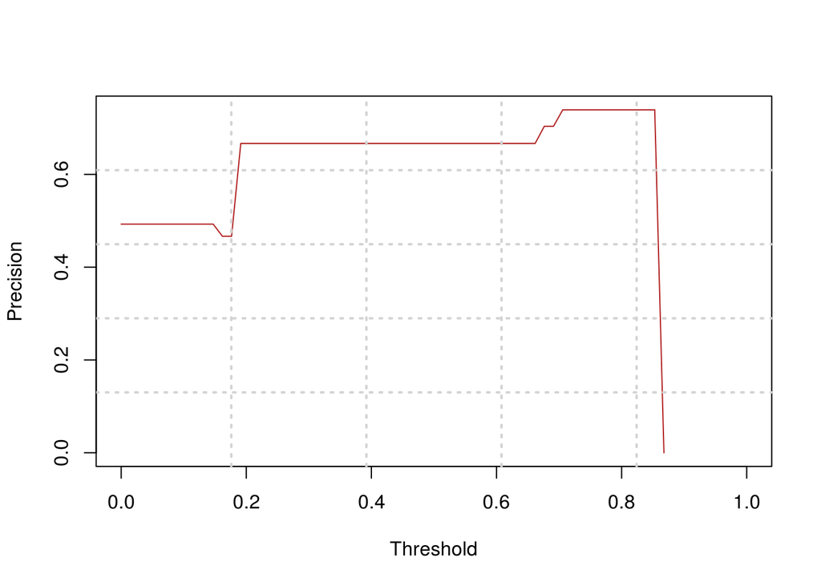

```r
> plot(prec_rec1$threshold,prec_rec1$precision,xlab="Threshold",ylab="Precision", type="l",col="firebrick")
> grid(5, 5, lwd = 2)
```

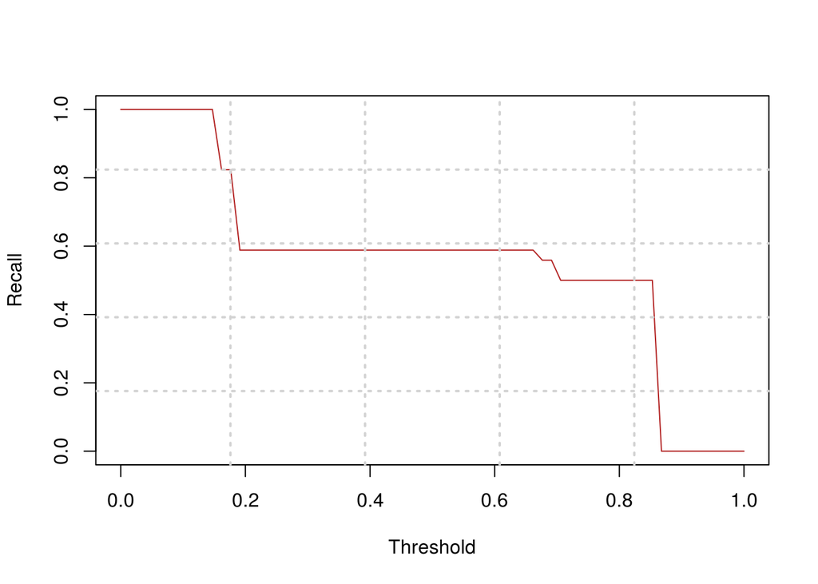

```r
> plot(prec_rec1$threshold,prec_rec1$recall,xlab="Threshold",ylab="Recall", type="l",col="firebrick")
> grid(5, 5, lwd = 2)
```

The ROC plot suggests that the classifier is not working as well as expected.

The receiver operating characteristic (ROC) plot gives an overall idea of how well the classifier is working.

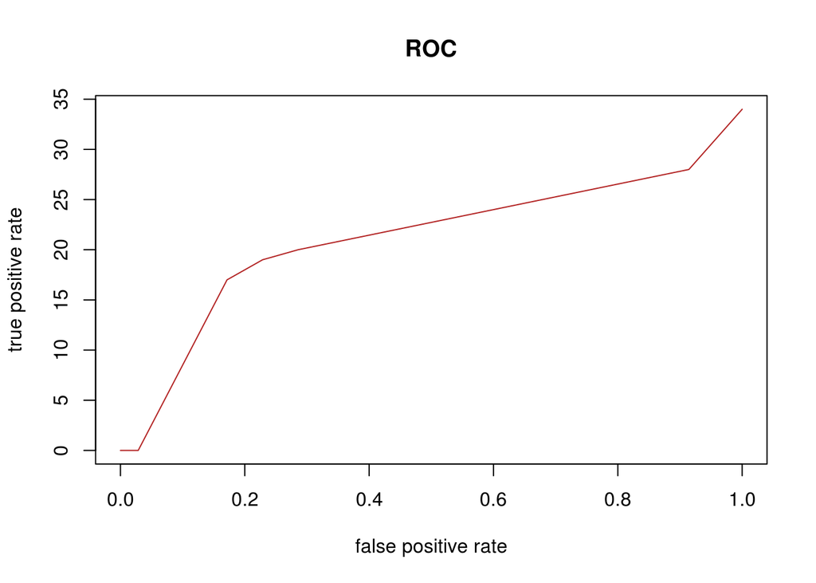

```r
> plot(prec_rec1$false_pos,prec_rec1$TP, type = "l",col="firebrick",main="ROC",xlab="false positive rate",ylab="true positive rate")
```

### Learning Curve

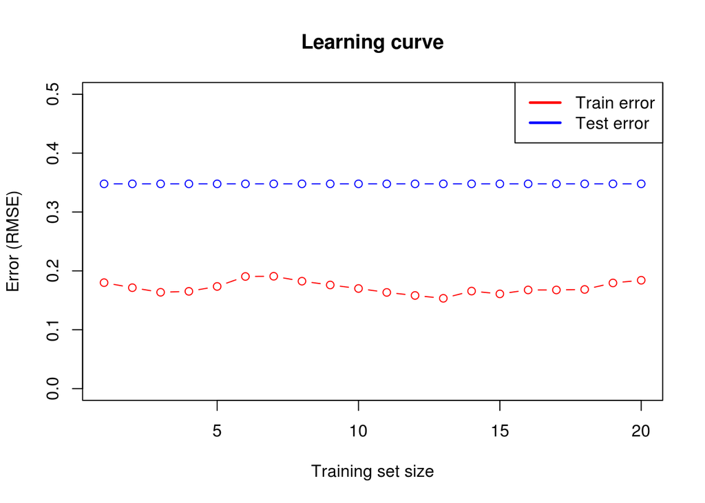

```r
> te_errs = c()
> tr_errs = c()
> te_actual = te_dat$output
> tr_sizes = seq(100, nrow(tr_dat), length.out=20)
>
>
>
>
> for (tr_size in tr_sizes) {
+  tr_dat1 = tr_dat[1:tr_size,]
+  tr_actual = tr_dat1$output
+  fit = rpart(output ~ chestpain + restbp + maxhr + chol , method = "class" , data = tr_dat)
+
+
+  # error on training set
+  tr_predicted = predict(fit, tr_dat1, type="class")
+  err = mean(tr_actual != tr_predicted)
+  tr_errs = c(tr_errs, err)
+
+
+
+  # error on test set
+  te_predicted = predict(fit, te_dat, type="class")
+  err = mean(te_actual != te_predicted)
+  te_errs = c(te_errs, err)
+ }
>
> plot(tr_errs,type = "b",col = "red", xlab = "Training set size", ylab = "Error (RMSE)",
+      main = "Learning curve", ylim=c(0,0.5))
>  lines(te_errs, type = "b", col = "blue")
>  legend('topright', c("Train error", "Test error"), lty = c(1,1), lwd = c(2.5, 2.5),
+         col = c("red", "blue"))
```

### Model 2

[figure not shown]

```r
> fit2 = rpart(output ~ chestpain + thal + fluor + maxhr + angina + dep,data=tr_dat, method="class")
>
> prp(fit2, extra=106, varlen=5,
+  main="classification tree for public/private univ.",
+  box.col=c("palegreen", "pink")[fit$frame$yval])
```

```r
> predicted = predict(fit2, te_dat, type="prob")
> predictors = as.data.frame(predicted)
> names(predictors) = c("zero","one")
> y = predictors$one
> predicts = as.numeric(y > 0.5)
> actuals = te_dat$output
> confusion_matrix = table(actuals, predicts)
> confusion_matrix
```

```
       predicts
actuals  0  1
      0 29  6
      1  6 28
```

Confusion matrix for the model, given a threshold of 0.5.

```r
> confusion_matrix
```

```
       predicts
actuals  0  1
      0 29  6
      1  6 28
```

As we can see, the accuracy of the model is improved.

```r
>  succ_rate = mean(predicts == actuals)
>  round(succ_rate, 3)
```

```
[1] 0.826
```

Features ‘chestpain’ and ‘thal’ seem to be the most relevant predictors.

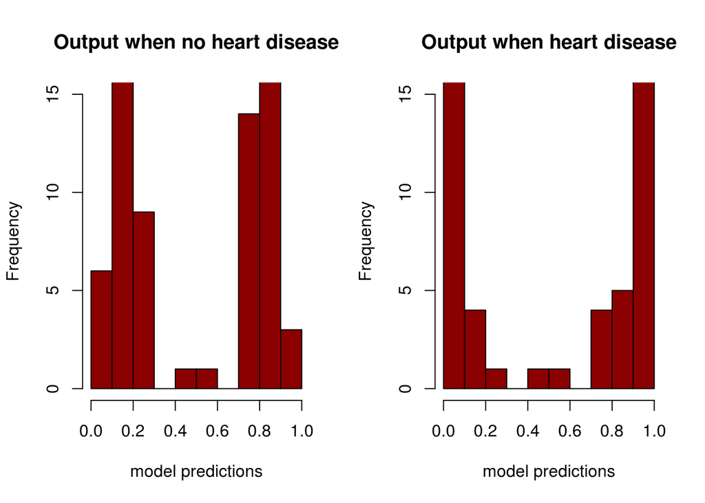

```r
> par(mfrow=c(1,2))
>  hist(predicted[actuals == 0], main="Output when no heart disease", breaks=10, xlim=c(0,1), ylim=c(0,15),col="red4", xlab="model predictions")
>
>  hist(predicted[actuals == 1], main="Output when heart disease", breaks=10, xlim=c(0,1), ylim=c(0,15), col="red4", xlab="model predictions")
```

Double density plot for the this model:

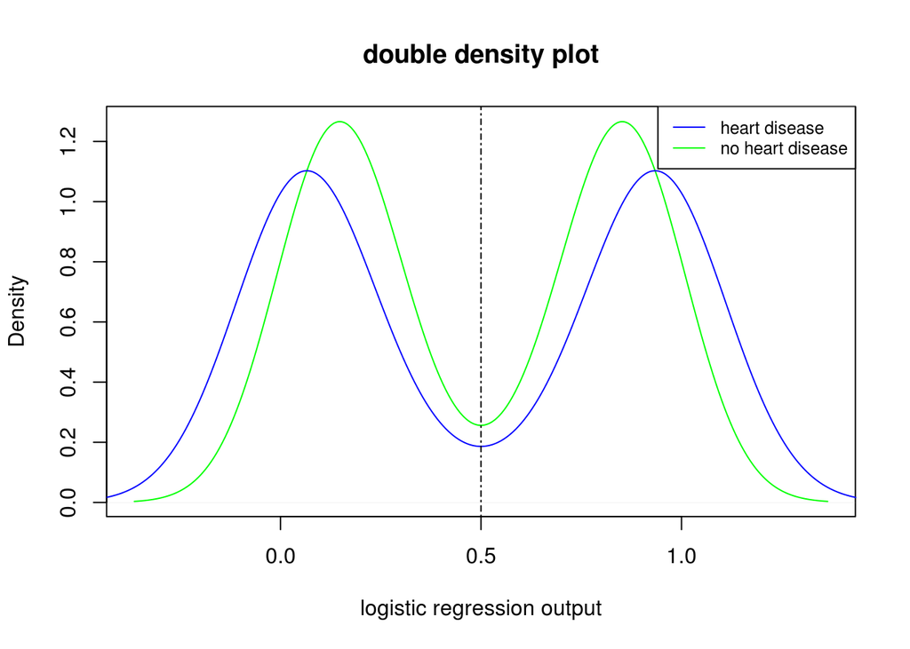

```r
>  par(mfrow=c(1,1))
>  plot(density(predicted[actuals == 0]), main="double density plot", col="green",xlab="logistic regression output")
>  lines(density(predicted[actuals == 1]),col="blue")
>  abline(a=NULL,b=0,h=NULL,v=0.5,lty=4)
>  legend("topright", legend=c("heart disease", "no heart disease"),col=c("blue", "green"), lty=1:1, cex=0.8)
```

```r
> prec=prec_rec1
> prec_rec1 = prec_recall_summary(predicts, actuals)
```

The ROC plot shows improved classifier performance, compared to our previous model.

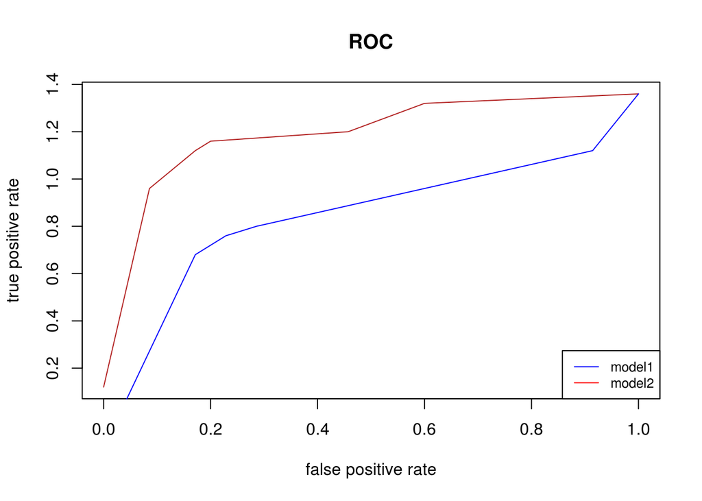

```r
> plot(prec_rec1$false_pos,prec_rec1$TP/25, type = "l",col="firebrick",main="ROC", xlab="false positive rate",ylab="true positive rate")
> lines(prec$false_pos,prec$TP/25, type = "l",col="blue")
> legend("bottomright", legend=c("model1", "model2"),col=c("blue", "red"), lty=1:1, cex=0.8)
```

### Learning Curve

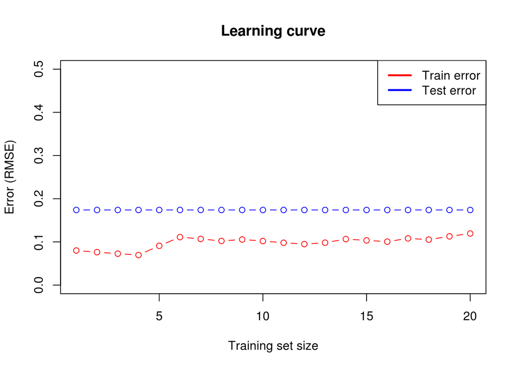

```r
> te_errs = c()
> tr_errs = c()
> te_actual = te_dat$output
> tr_sizes = seq(100, nrow(tr_dat), length.out=20)
>
>
>
>
> for (tr_size in tr_sizes) {
+  tr_dat1 = tr_dat[1:tr_size,]
+  tr_actual = tr_dat1$output
+  fit = rpart(output ~ chestpain + thal + fluor + maxhr + angina + dep,data=tr_dat, method="class")
+
+
+  # error on training set
+  tr_predicted = predict(fit, tr_dat1, type="class")
+  err = mean(tr_actual != tr_predicted)
+  tr_errs = c(tr_errs, err)
+
+
+
+  # error on test set
+  te_predicted = predict(fit, te_dat, type="class")
+  err = mean(te_actual != te_predicted)
+  te_errs = c(te_errs, err)
+ }
>
> plot(tr_errs,type = "b",col = "red", xlab = "Training set size", ylab = "Error (RMSE)",
+      main = "Learning curve", ylim=c(0,0.5))
>  lines(te_errs, type = "b", col = "blue")
>  legend('topright', c("Train error", "Test error"), lty = c(1,1), lwd = c(2.5, 2.5),
+         col = c("red", "blue"))
```

### Conclusion

We can see that our model is better fit when use only predictors that are relevant. Furthermore, it is important to notice the improvement from model2 compared to model1 based on the accuracy and roc derived from the data.